# Foundations of Data Science - Final Projects

Project nº1 - A rental website

Patricio Coutinho da Silva

2021/08/15

```r
library(tibble)
library(dplyr)
library(readr)
library(lubridate)
library(janitor)
library(ggplot2)
library(tidyr)
library(readxl)
library(openxlsx)
library(DBI)
library(stringr)
library(infer)
library(rvest)
library(leaflet)
library(purrr)
library(magrittr)
library(httr)
library(ggmap)
```

## Part 1

Get the full dataset out of the site. Your code should end up with a `tibble` of a bit more than `600` rows and `9` columns. Make sure you take the time to convert each column to the right type so not all are `character` columns.

```r
simple <- read_html("https://epfl-exts.github.io/rental-scrape")

scrape_adress <-
simple %>%
  html_nodes(".sec-info .address") %>%
  html_text()

scrape_price <-
simple %>%
  html_nodes(".price .float-right") %>%
  html_text()

scrape_objecttype <-
simple %>%
  html_nodes(".bg-text .object-type") %>%
  html_text()

scrape_floor <-
simple %>%
  html_nodes(".floor strong") %>%
  html_text()

scrape_living_space <-
simple %>%
  html_nodes(".living-space strong") %>%
  html_text()

scrape_rooms <-
simple %>%
  html_nodes(".rooms strong") %>%
  html_text()

scrape_usable_surface <-
simple %>%
  html_nodes(".usable-surface strong") %>%
  html_text()

scrape_availability <-
simple %>%
  html_nodes(".availability strong") %>%
  html_text()

scraped_tibble <-
  tibble(object_type = scrape_objecttype, address = scrape_adress, floor = scrape_floor, living_space = scrape_living_space, rooms = scrape_rooms, usable_surface = scrape_usable_surface, availability = scrape_availability, price = scrape_price) %>%

  mutate(floor = as.numeric(floor), living_space = as.numeric(str_remove(living_space, " m2")), rooms = as.numeric (rooms), usable_surface = as.numeric(str_remove(usable_surface, " m2")), price = as.numeric(str_remove(price, " CHF")), address_cp = substr(substring(address, regexpr(", 1", address) +2),0,4))

  scraped_tibble
```

| object_type | address | floor | living_space | rooms | usable_surface | availability | price | address_cp |
| --- | --- | --- | --- | --- | --- | --- | --- | --- |
| Apartment | Rue de la Terrassière 58, 1207 Genève | 4 | 63 | 3.0 | NA | 01 Oct 2018 | 1900 | 1207 |
| Apartment | Address on request, 1290 Versoix | NA | 185 | 4.0 | NA | 01 Aug 2018 | 4500 | 1290 |
| Apartment | Rue Liotard 46, 1202 Genève | 50 | NA | 4.0 | NA | 01 Aug 2018 | 2100 | 1202 |
| Single house | Address on request, 1248 Hermance | 3 | 170 | 6.0 | NA | NA | 5500 | 1248 |
| Apartment | Avenue Henri-Golay 36, 1219 Châtelaine | 1 | 73 | 4.0 | NA | 01 Aug 2018 | 2340 | 1219 |
| Apartment | Address on request, 1204 Genève | 2 | NA | 4.5 | NA | NA | 2895 | 1204 |
| Apartment | Rue des Lattes 51, 1217 Meyrin | 11 | 73 | 4.0 | NA | 01 Oct 2018 | 1980 | 1217 |
| Roof flat | Chemin de l'Escalade 3, 1206 Genève | 6 | 150 | 5.0 | NA | Immediately | NA | 1206 |
| Apartment | Rue des Rois 1, 1204 Genève | 5 | 117 | 4.0 | NA | 01 Sep 2018 | 3080 | 1204 |
| Apartment | Promenade Champs-Fréchets 8-12, 1217 Meyrin | 2 | 75 | 4.0 | NA | 16 Sep 2018 | 2010 | 1217 |

[output cut: 602 more lines]

## Part 2

Create a scatterplot showing how price evolves with living space of a flat.

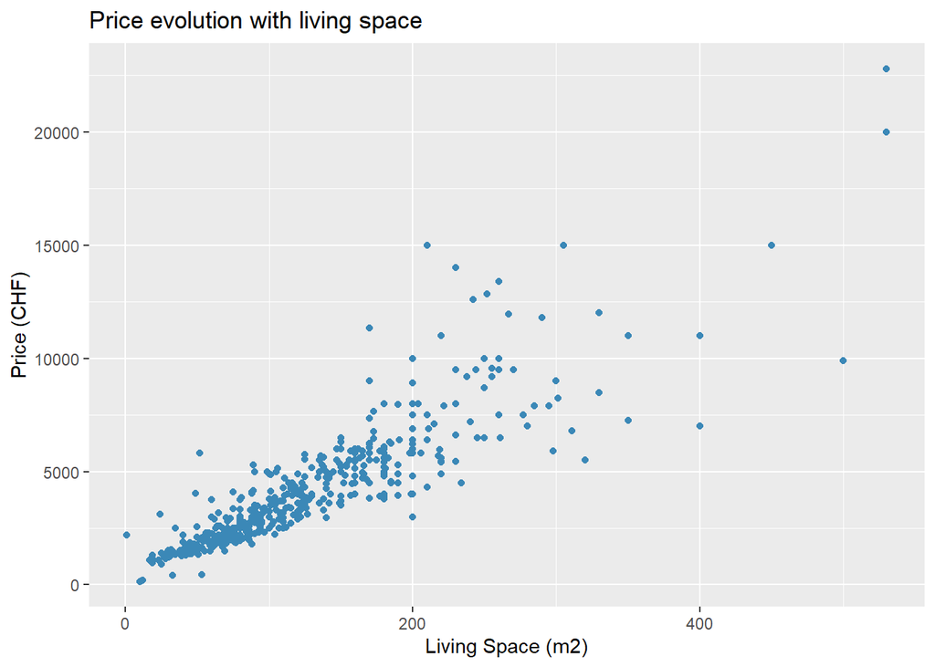

```r
tibble_livingspace <-
scraped_tibble %>%
  filter(living_space > 0, price > 0)


tibble_livingspace %>%
  ggplot(aes(x = living_space, y = price)) +
  geom_point( color = "#3B88B7") +
  labs(title = "Price evolution with living space",
       y = "Price (CHF)", x = "Living Space (m2)")
```

## Part 3

Create a bar plot showing the number of properties by postcode. Is this agency more “active” in certain areas?

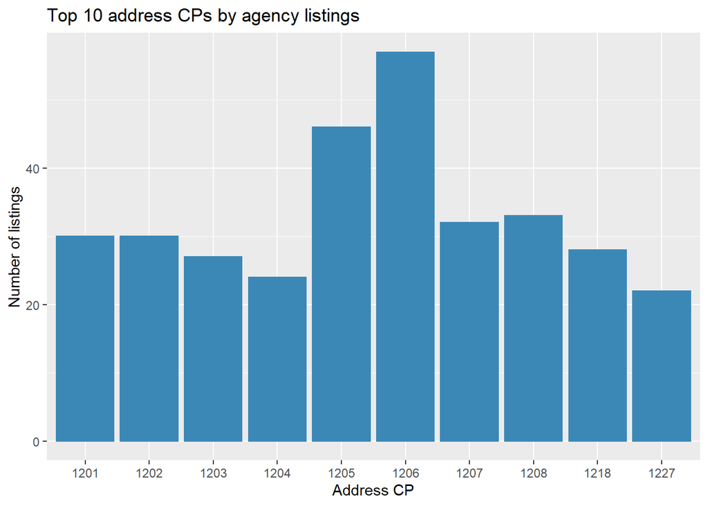

```r
tibble_postcode <-
  scraped_tibble %>%
  filter(address_cp > 0) %>%
  count(address_cp, name = "rent_id") %>%
  arrange(desc(rent_id)) %>%
  head(10)

  ggplot(data = tibble_postcode,
       mapping = aes(x = address_cp,
                     y = rent_id)) +
  geom_col(color = "#3B88B7", fill = "#3B88B7") +
  labs(title = "Top 10 address CPs by agency listings", y = "Number of listings", x = "Address CP")
```

In the following plot we can observe the top 10 postcodes respect to the number of properties for rent. The agency shows higher activity on CPs **1206** & **1205** respectively.

## Part 4

Create a more complex scatterplot, showing how price evolves with living space of the flat by postcode and by floor. You can use colors and/or facets to make the categories visible.

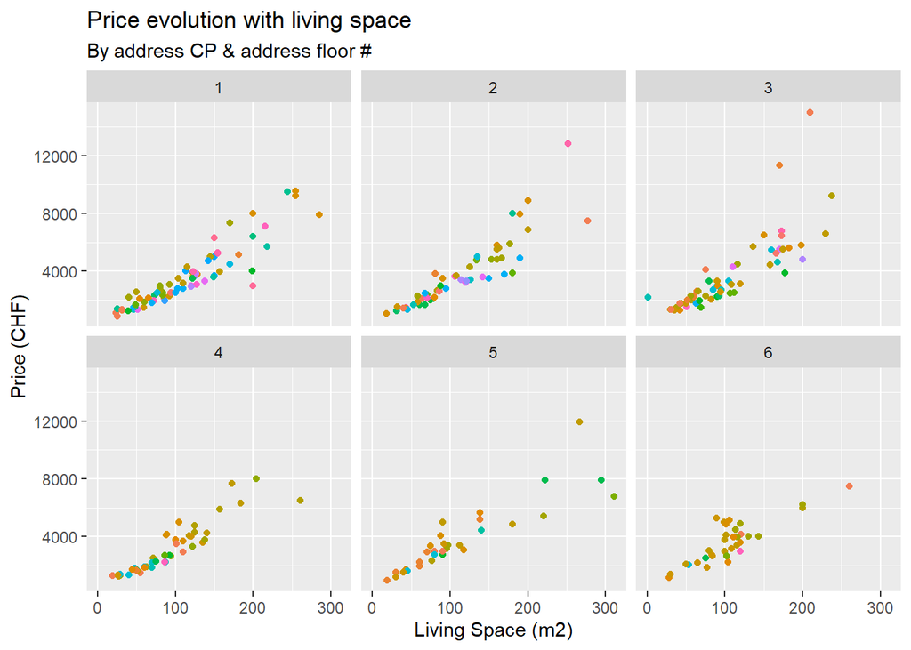

```r
tibble_facetplot <-
scraped_tibble %>%
  filter(living_space > 0, price > 0, floor > 0, floor < 7)


tibble_facetplot %>%
  ggplot(aes(x = living_space, y = price, color = address_cp)) +
  geom_point() +
  facet_wrap(vars(floor),ncol = 3) +
  theme(legend.position = "none") +
  labs(title= "Price evolution with living space", subtitle = "By address CP & address floor #", y = "Price (CHF)", x = "Living Space (m2)")
```

## Part 5

Can you see any trends for listings with addresses only available on demand? Are they more expensive or less? Bigger living space? Higher floor?

Boxplot or violin plots work really well to compare distributions of values between groups. So use one for each of the three questions above.

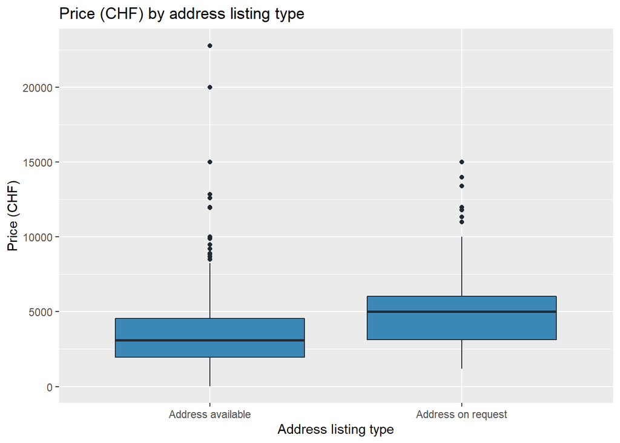

```r
tibble_advanced_address <-

  scraped_tibble %>%
    mutate(address_available = if_else(str_detect(address, pattern = "Address on request"),"Address on request","Address available"))


tibble_advanced_address %>%
  ggplot(mapping = aes(x = address_available, y = price)) +
  geom_boxplot() +
  geom_boxplot(fill= "#3B88B7", color= "#222A35") +
  labs(title = "Price (CHF) by address listing type", y = "Price (CHF)", x = "Address listing type")
```

The median of price is higher for listings with address on request.

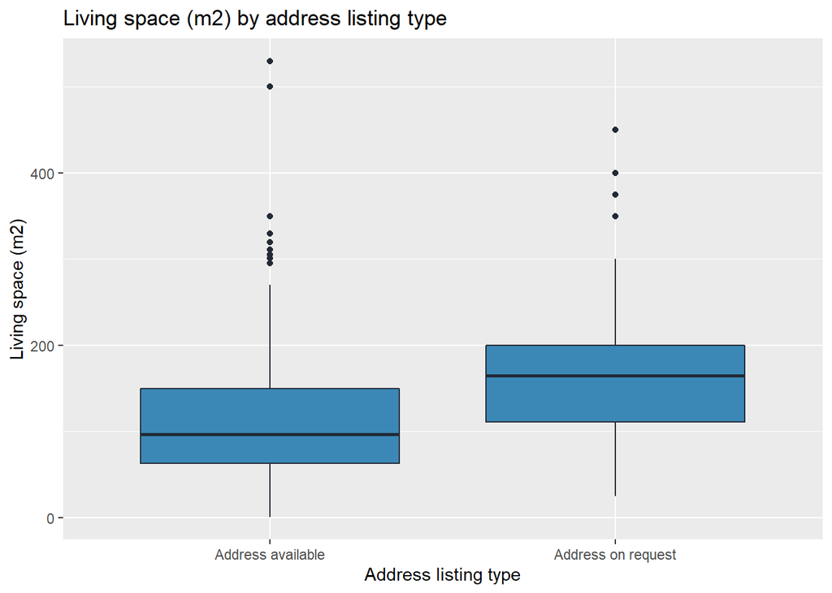

```r
tibble_advanced_address %>%
  ggplot(mapping = aes(x = address_available, y = living_space)) +
  geom_boxplot() +
  geom_boxplot(fill= "#3B88B7", color= "#222A35") +
  labs(title = "Living space (m2) by address listing type", y = "Living space (m2)",
       x = "Address listing type")
```

The median of living space is higher for listings with address on request.

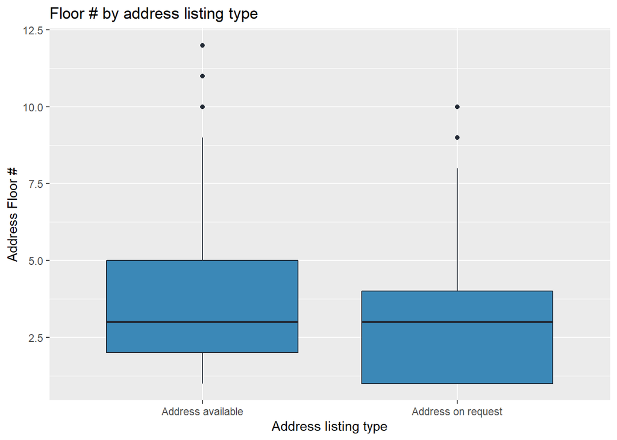

```r
tibble_advanced_address %>%
  filter(floor < 15) %>%   # to reduce two points that are only making plot more diffitul to read
  ggplot(mapping = aes(x = address_available, y = floor)) +
  geom_boxplot() +
  geom_boxplot(fill= "#3B88B7", color= "#222A35") +
  labs(title = "Floor # by address listing type", y = "Address Floor #", x = "Address listing type")
```

The median of floor # is very similar for the two types of listings in scope.

## Part 6

In this question, use the same groups as above: flats whose addresses are only available on demand versus other flats. Make a table summarising group size, median, average, standard-deviation, minimum and maximum of the variable price per square-meter (expressed in CHF/$m^2$).

Have a look at the statistics. What is your impression, is there a difference in price per square-meter for these 2 groups of flats, and in what direction?

After writing down your initial impression, use a t-test to statistically compare the average price per square-meter for these types of flats.

What is your conclusion, is your initial impression statistically supported by the results of the t-test?

```r
tibble_advanced_address %>%
  mutate(price_per_m2 = price / living_space) %>%
  group_by(address_available) %>%
  summarise(group_size = n(), median = median(price_per_m2, na.rm = TRUE),
            mean = mean(price_per_m2, na.rm = TRUE), standard_dev = sd(price_per_m2, na.rm = TRUE),
            minimum = min(price_per_m2, na.rm = TRUE), maximum = max (price_per_m2, na.rm = TRUE))
```

| address_available | group_size | median | mean | standard_dev | minimum | maximum |
| --- | --- | --- | --- | --- | --- | --- |
| Address available | 460 | 33.18466 | 39.81016 | 109.191737 | 8.301887 | 2180.00000 |
| Address on request | 152 | 33.33333 | 34.22823 | 9.459612 | 17.500000 | 71.42857 |

```r
tibble_t_test_final <-
  tibble_advanced_address %>%
  mutate(price_per_m2 = price / living_space)
```

No huge differences observed on medians of price/$m^2$. Mean shows that apparently flats with address available are slightly more expensive on average, however, this could be heavily impacted by extreme values (highest values or lowest values) in the dataset.

```r
my_t_test <-
  tibble_t_test_final %>%
  filter(price > 0, living_space >0) %>%
  t_test(formula = price_per_m2 ~ address_available,
  order = c("Address available", "Address on request"),
  conf_level = 0.95)
  my_t_test
```

| statistic | t_df | p_value | alternative | lower_ci | upper_ci |
| --- | --- | --- | --- | --- | --- |
| 0.9970477 | 408.0004 | 0.3193323 | two.sided | -5.423498 | 16.58737 |

T-test result shows a **p-value of 0.31**, which is not strong enough to reject the null hypothesis: we can conclude both type of listings have a similar price/$m^2$.

## Part 7

Do the same as in part 6, but now looking at the variable price (expressed in CHF).

Compare the results of price per square-meter with those for price. Are there differences between the results? How would you interpret these differences?

```r
tibble_advanced_address %>%
  group_by(address_available) %>%
  summarise(group_size = n(), median = median(price, na.rm = TRUE), mean = mean(price, na.rm = TRUE), standard_dev = sd(price, na.rm = TRUE), minimum = min(price, na.rm = TRUE), maximum = max (price, na.rm = TRUE))
```

| address_available | group_size | median | mean | standard_dev | minimum | maximum |
| --- | --- | --- | --- | --- | --- | --- |
| Address available | 460 | 3100 | 3658.224 | 2530.646 | 30 | 22800 |
| Address on request | 152 | 5000 | 5203.531 | 2734.404 | 1180 | 15000 |

## Part 8

Convert a subset of 30 addresses to latitude and longitude using an API and plot them on a map using {ggmap} (or {leaflet} if you cannot get {ggmap} to work).

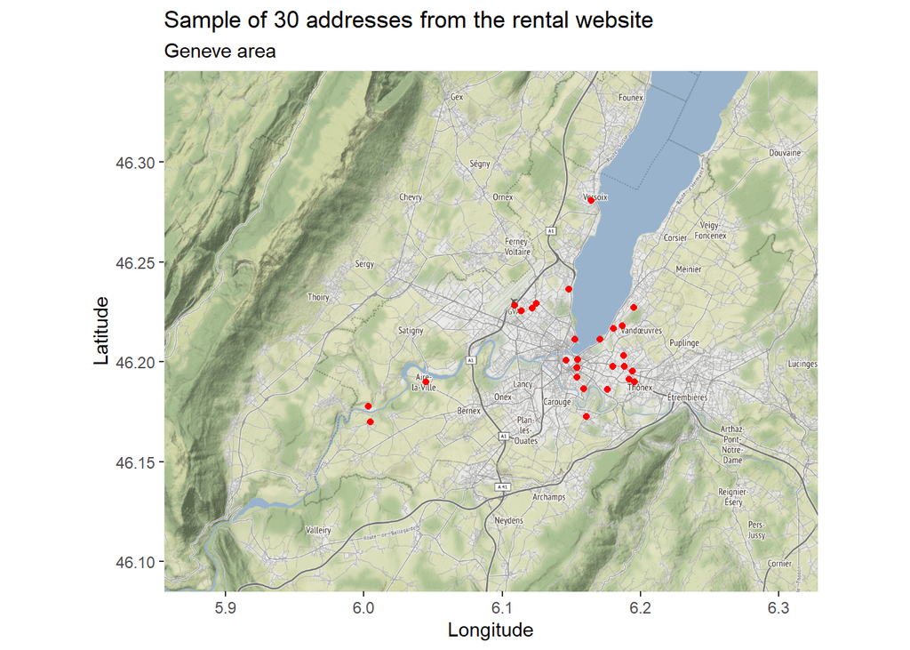

```r
tibble_30_addresses <-
  tibble_advanced_address %>%
  filter(address_available == "Address available", ) %>%
  arrange(desc(living_space)) %>%
  head(30)

vector30 <- tibble_30_addresses %>%
  pull(address) %>%
  str_replace_all(" ", "+") %>%
  str_replace(", ", "+") %>%
  str_replace_all(",", "") %>%
  paste0("+CH")

results_30_adresses <-str_glue("https://geocode.xyz/{vector30}?json=1") %>%
  map(GET) %>%
  map(content)

coordinate_points <-
  results_30_adresses %>%
  map_df(magrittr::extract, c("longt", "latt")) %>%
  mutate(longt = as.numeric(longt), latt = as.numeric(latt))

Geneve_area <- c(left = 5.855600, bottom = 46.085028, right = 6.327956, top = 46.345574)

Zurich_map <- get_stamenmap(bbox = Geneve_area, zoom = 12)
ggmap(Zurich_map) +
  geom_point(data = coordinate_points, aes(x = longt, y = latt), color = "red") +
  labs(title = "Sample of 30 addresses from the rental website", subtitle="Geneve area", x="Longitude", y="Latitude")
```